# GEDI ratio mode: Splicing

In this tutorial, we are going to introduce splicing analysis using GEDI in the ratio mode, focused on performing exon-skipping event analysis. We will be using the data derived from two studies: [Tasic 2016](https://www.nature.com/articles/nn.4216) and [Tasic 2018](https://www.nature.com/articles/s41586-018-0654-5). These two studies profiled neocortex tissue in adult mice using full-length single-cell sequencing protocols (SMARTer and SMART-seq).

# 01 - Pre-processing

## Load libraries

```r
library(HDF5Array)
library(ggplot2)
library(Matrix)
library(RColorBrewer)
library(uwot)
library(GEDI)
set.seed(43)
```

## Loading data

To run GEDI in this mode, we need two types of observations for each exon skipping event:

- 1. The number of reads that support an exon inclusion event.
- 2. The number of reads that support an exon exclusion event.

In this case, the data has been processed using the [Quantas pipeline](https://zhanglab.c2b2.columbia.edu/index.php/Quantas_Documentation), which generated two types of observations for each exon skipping event. They are stored as M1(inclusion) and M2(exclusion) in our SingleCell Experiment Object.

We can load the data.

```r
sce<- loadHDF5SummarizedExperiment(dir="./my_h5_se")
sce
```

```
## class: SingleCellExperiment
## dim: 14267 25352
## metadata(0):
## assays(5): Y raw_M1 raw_M2 norm_M1 norm_M2
## rownames(14267):
##   CA-100036521-14294-117618-117680-170683[INC][40/1][DNT]
##   CA-100036521-117680-144789-144867-170683[INC][3/42][DNT] ...
##   CA-17380-8143-33842-34004-34913[INC][36/1]
##   CA-17387-3370-5354-5521-7141[INC][1/115][UPT]
## rowData names(0):
## colnames(25352): SRR2138604 SRR2138605 ... SRR8322945 SRR8322946
## colData names(4): Sample SRA_Run major_cell_type cell_cluster
## reducedDimNames(0):
## altExpNames(0):
```

We access the exon inclusion and exclusion events.

```r
meta<- data.frame(colData(sce)) # Metadata
M1<- assay(sce, "raw_M1") # inclusion counts
M2<- assay(sce, "raw_M2") # exclusion counts
head(M1[,1:10])
```

```
## <6 x 10> sparse matrix of class DelayedMatrix and type "double":
##                                                          SRR2138604 ...
## CA-100036521-14294-117618-117680-170683[INC][40/1][DNT]          66   .
## CA-100036521-117680-144789-144867-170683[INC][3/42][DNT]          0   .
## CA-100037278-10390-10961-11073-12015[INC][5/2]                    0   .
## CA-100037283-3239-5230-5291-8262[INC][105/1][UPT]                 0   .
## CA-100039707-3310-7049-7311-33813[INC][1/3][UPT][DNT]             0   .
## CA-100039795-19480-40277-40334-43452[INC][6/2]                    0   .
##                                                          SRR2138614
## CA-100036521-14294-117618-117680-170683[INC][40/1][DNT]           8
## CA-100036521-117680-144789-144867-170683[INC][3/42][DNT]          0
## CA-100037278-10390-10961-11073-12015[INC][5/2]                    0
## CA-100037283-3239-5230-5291-8262[INC][105/1][UPT]                 0
## CA-100039707-3310-7049-7311-33813[INC][1/3][UPT][DNT]             0
## CA-100039795-19480-40277-40334-43452[INC][6/2]                    0
```

```r
head(M2[,1:10])
```

```
## <6 x 10> sparse matrix of class DelayedMatrix and type "double":
##                                                          SRR2138604 ...
## CA-100036521-14294-117618-117680-170683[INC][40/1][DNT]           0   .
## CA-100036521-117680-144789-144867-170683[INC][3/42][DNT]         45   .
## CA-100037278-10390-10961-11073-12015[INC][5/2]                    0   .
## CA-100037283-3239-5230-5291-8262[INC][105/1][UPT]                 0   .
## CA-100039707-3310-7049-7311-33813[INC][1/3][UPT][DNT]             0   .
## CA-100039795-19480-40277-40334-43452[INC][6/2]                    0   .
##                                                          SRR2138614
## CA-100036521-14294-117618-117680-170683[INC][40/1][DNT]           0
## CA-100036521-117680-144789-144867-170683[INC][3/42][DNT]          7
## CA-100037278-10390-10961-11073-12015[INC][5/2]                    0
## CA-100037283-3239-5230-5291-8262[INC][105/1][UPT]                 0
## CA-100039707-3310-7049-7311-33813[INC][1/3][UPT][DNT]             0
## CA-100039795-19480-40277-40334-43452[INC][6/2]                    0
```

M1 (inclusion) and M2 (exclusion) are matrices that have the exon skipping events in the rows and cells in the columns.

## Filter cells and genes

We filter cells that have low number of inclusion and exclusion counts

```r
# Filter cels
filter<- which(log10(colSums(M1)) > 4.5 & log10(colSums(M2)) > 4)
length(filter)
```

```
## [1] 25352
```

```r
M1<- M1[,filter]
M2<- M2[,filter]
```

Now, we filter low-expressed events. We keep events that have more than 50 exon inclusion counts and more than 50 exon exclusion counts across the entire dataset.

```r
# Filter events
filter <- which( rowSums(M1) > 50 & rowSums(M2) > 50 ) # Filter events
length(filter)
```

```
## [1] 14267
```

```r
M1<- M1[filter,]
M2<- M2[filter,]
```

We can plot the distribution of the total number of events per cell after filtering

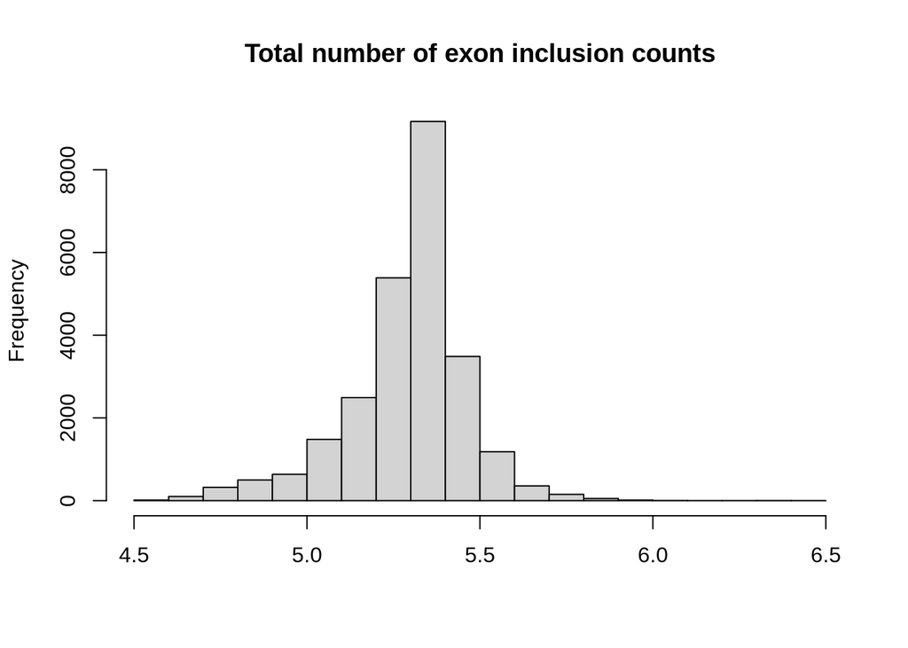

```r
hist(log10(colSums(M1)), main="Total number of exon inclusion counts", xlab="")
```

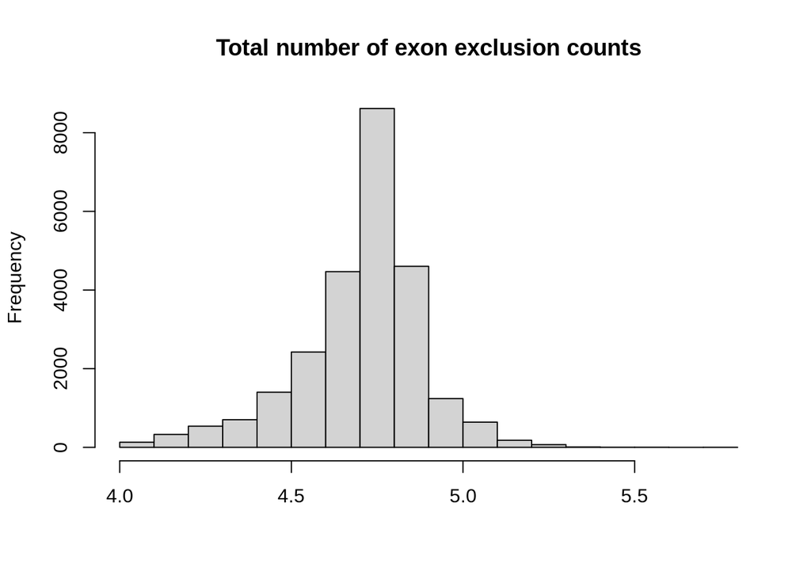

```r
hist(log10(colSums(M2)), main="Total number of exon exclusion counts", xlab="")
```